# Integrating [TCGA](http://cancergenome.nih.gov/abouttcga) Data

[RTCGA](http://rtcga.github.io/RTCGA/) Workflow

[Marcin Kosiński](http://r-addict.com/About.html)

June 24, 2016

# About TCGA

# About TCGA

> The Cancer Genome Atlas (TCGA) is a comprehensive and coordinated effort to accelerate our understanding of the molecular basis of cancer through the application of genome analysis technologies, including large-scale genome sequencing.

> … has generated comprehensive, multi-dimensional maps of the key genomic changes in 33 types of cancer. The TCGA dataset, comprising more than two petabytes of genomic data, has been made publically available, and this genomic information helps the cancer research community to improve the prevention, diagnosis, and treatment of cancer.

Source: http://cancergenome.nih.gov/

Data: http://gdac.broadinstitute.org/

# RTCGA

# RTCGA Family Members

Software package

- [RTCGA](http://bioconductor.org/packages/RTCGA/)

[figure not shown]

Data packages available on Bioconductor - [RTCGA.mutations](http://bioconductor.org/packages/RTCGA.mutations/) - [RTCGA.rnaseq](http://bioconductor.org/packages/RTCGA.rnaseq/) - [RTCGA.clinical](http://bioconductor.org/packages/RTCGA.clinical/) - [RTCGA.PANCAN12](http://bioconductor.org/packages/RTCGA.PANCAN12/) - [RTCGA.mRNA](http://bioconductor.org/packages/RTCGA.mRNA/) - [RTCGA.miRNASeq](http://bioconductor.org/packages/RTCGA.miRNASeq/) - [RTCGA.RPPA](http://bioconductor.org/packages/RTCGA.RPPA/) - [RTCGA.CNV](http://bioconductor.org/packages/RTCGA.CNV/) - [RTCGA.methylation](http://bioconductor.org/packages/RTCGA.methylation/)

# RTCGA Workflow

[figure not shown]

# About RTCGA

- [We](https://github.com/orgs/RTCGA/people) converted selected datasets from The Cancer Genome Atlas study into few separate data packages.
- These R data packages make selected datasets easier to access, manage and analyze with RTCGA software package.
- Data sets in RTCGA family are large and cover complex relations between clinical outcomes and genetic background.
- Website: rtcga.github.io/RTCGA/

# Learn More

# Learn More: Use Cases

- [Examples of Visualizations](http://rtcga.github.io/RTCGA/Visualizations.html)
- [TCGA and The Curse of BigData](http://rtcga.github.io/RTCGA/Usecases.html)

Blog posts

- [Quick Guide](http://r-addict.com/2016/05/04/RTCGA-Quick-Guide.html)
- [Venn Diagram Comparison of Boruta, FSelectorRcpp and GLMnet Algorithms on TCGA Data](http://www.r-bloggers.com/venn-diagram-comparison-of-boruta-fselectorrcpp-and-glmnet-algorithms/)

# Future Plans

# Future Plans: [ExperimentHub](http://bioconductor.org/packages/ExperimentHub/)

Submit data from the newest TCGA release to [ExperimentHub](http://bioconductor.org/packages/ExperimentHub/) - https://github.com/RTCGA/RTCGA/issues/85

# I still have some time?

# Examples of Visualizations

`kmTCGA()` - based on [survminer](https://cran.r-project.org/web/packages/survminer/index.html)

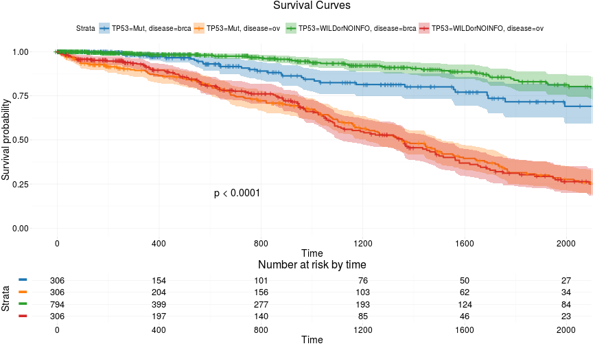

# Examples of Visualizations

`pcaTCGA()` - based on ggbiplot

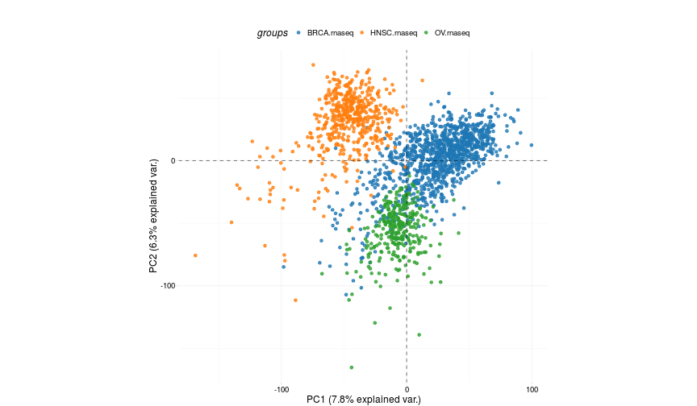

# Examples of Visualizations

`boxplotTCGA()`

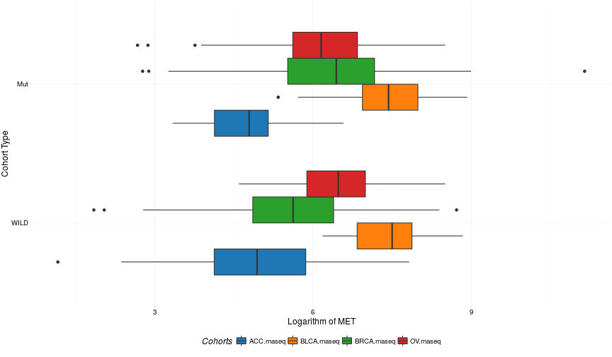

# Examples of Visualizations

`heatmapTCGA()` - based [on this blog post](http://www.r-bloggers.com/making-faceted-heatmaps-with-ggplot2/) by [hrbrmstr](http://www.r-bloggers.com/author/hrbrmstr/)

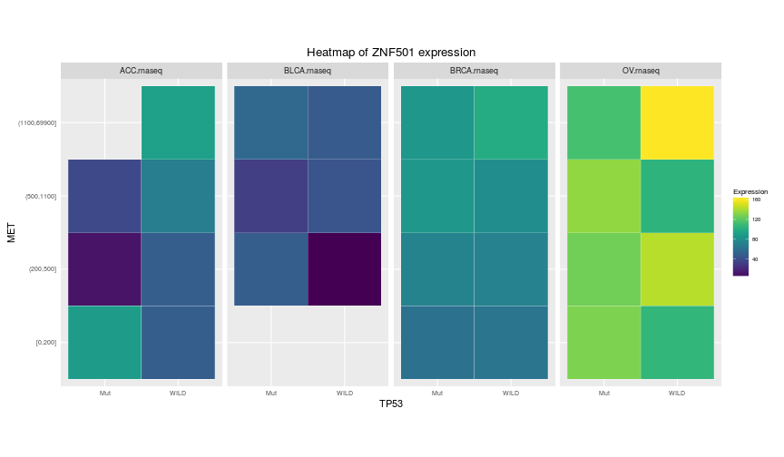

# Thanks For Your Attention